# Data Science for Developers

### Modeling the Expert - ROC

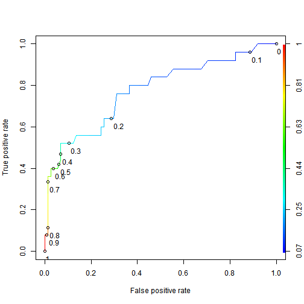

```r
# Install and load ROCR package
#install.packages("ROCR")
library(ROCR)

# Prediction function
ROCRpred = prediction(predictTrain, qualityTrain$PoorCare)

# Performance function
ROCRperf = performance(ROCRpred, "tpr", "fpr") #This defines what we want to plot on x & y axis

# Plot Reciever Operator Characteristic curve
plot(ROCRperf, colorize=TRUE, print.cutoffs.at=seq(0,1,by=0.1), text.adj=c(-0.2,1.7))
```

### Modeling the Expert - Conclusion

**Given this ROC curve, which threshold would you pick if you wanted to correctly identify a small group of patients who are receiving the worst care with high confidence?**

*0.7*

EXPLANATION:The threshold 0.7, since at this threshold we make very few false positive mistakes, and identify about 35% of the true positives.

The threshold t = 0.8 is not a good choice, since it makes about the same number of false positives, but only identifies 10% of the true positives.

The thresholds 0.2 and 0.3 both identify more of the true positives, but they make more false positive mistakes, so our confidence decreases.

**Which threshold would you pick if you wanted to correctly identify half of the patients receiving poor care, while making as few errors as possible?**

*0.3*

EXPLANATION:The threshold 0.3 is the best choice in this scenerio. The threshold 0.2 also identifies over half of the patients receiving poor care, but it makes many more false positive mistakes. The thresholds 0.7 and 0.8 don't identify at least half of the patients receiving poor care.

### Classification and Regression Trees (CART)

This plot shows sample data for two independent variables, *x* and *y*, and each data point is colored by the outcome variable, red or gray.

CART tries to split this data into subsets so that each subset is as pure or homogeneous as possible.

A *CART* model is represented by a **tree**.

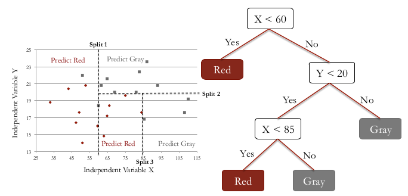

The first three splits that CART would create are shown here.

Then the standard prediction made by a *CART* model is just a **majority vote** within each subset.

Some advantages of *CART* are that:

- it **does not assume a linear model**, like logistic regression or linear regression, and
- it is a **very interpretable** model.

### Predicting Supreme Court Decisions

```r
stevens = read.csv("stevens.csv", stringsAsFactor = TRUE)
str(stevens)
```

```
'data.frame':   566 obs. of  9 variables:
 $ Docket    : Factor w/ 566 levels "00-1011","00-1045",..: 63 69 70 145 97 181 242 289 334 436 ...
 $ Term      : int  1994 1994 1994 1994 1995 1995 1996 1997 1997 1999 ...
 $ Circuit   : Factor w/ 13 levels "10th","11th",..: 4 11 7 3 9 11 13 11 12 2 ...
 $ Issue     : Factor w/ 11 levels "Attorneys","CivilRights",..: 5 5 5 5 9 5 5 5 5 3 ...
 $ Petitioner: Factor w/ 12 levels "AMERICAN.INDIAN",..: 2 2 2 2 2 2 2 2 2 2 ...
 $ Respondent: Factor w/ 12 levels "AMERICAN.INDIAN",..: 2 2 2 2 2 2 2 2 2 2 ...
 $ LowerCourt: Factor w/ 2 levels "conser","liberal": 2 2 2 1 1 1 1 1 1 1 ...
 $ Unconst   : int  0 0 0 0 0 1 0 1 0 0 ...
 $ Reverse   : int  1 1 1 1 1 0 1 1 1 1 ...
```

### Predicting Supreme Court Decisions - Data Set

| Variable | Description |
| --- | --- |
| Docket | A unique identifier for each case. |
| Term | The year of the case. |
| Circuit | The circuit court of origin of the case. One of 1st - ??? 11th, Federal, or D.C. |
| Issue | The issue area of the case. Examples are criminal procedure, civil rights, privacy, etc. |
| Petitioner | The type of petitioner in the case. Examples are an employer, an employee, the United States, etc. |
| Respondent | The type of respondent in the case. Examples are an employer, an employee, the United States, etc. |
| LowerCourt | The ideological direction of the lower court ruling, either liberal or conservative. |
| Unconst | Whether or not the petitioner argued that a law or practice is unconstitutional. |
| Reverse | Whether or not Justice Stevens voted to reverse the case. |

### Predicting Supreme Court Decisions - Summary

```r
summary(stevens)
```

```
     Docket         Term         Circuit                  Issue
 00-1011:  1   Min.   :1994   9th    :122   CriminalProcedure:132
 00-1045:  1   1st Qu.:1995   5th    : 53   JudicialPower    :102
 00-1072:  1   Median :1997   11th   : 49   EconomicActivity : 98
 00-1073:  1   Mean   :1997   7th    : 47   CivilRights      : 74
 00-1089:  1   3rd Qu.:1999   4th    : 46   DueProcess       : 43
 00-121 :  1   Max.   :2001   8th    : 44   FirstAmendment   : 39
 (Other):560                  (Other):205   (Other)          : 78
               Petitioner               Respondent    LowerCourt
 OTHER              :175   OTHER             :177   conser :293
 CRIMINAL.DEFENDENT : 89   BUSINESS          : 80   liberal:273
 BUSINESS           : 79   US                : 69
 STATE              : 48   CRIMINAL.DEFENDENT: 58
 US                 : 48   STATE             : 56
 GOVERNMENT.OFFICIAL: 38   EMPLOYEE          : 28
 (Other)            : 89   (Other)           : 98
    Unconst          Reverse
 Min.   :0.0000   Min.   :0.0000
 1st Qu.:0.0000   1st Qu.:0.0000
 Median :0.0000   Median :1.0000
 Mean   :0.2473   Mean   :0.5459
 3rd Qu.:0.0000   3rd Qu.:1.0000
 Max.   :1.0000   Max.   :1.0000
```

### Predicting Supreme Court Decisions - Logistic Regression

```r
#remove the variables that are not interesting, `Docket` and `Term`.
stevensless <- stevens[, -c(1, 2)]
library(caTools)
set.seed(3000) # to get the same split everytime
spl1 = sample.split(stevensless$Reverse, SplitRatio = 0.7)
Train1 = subset(stevensless, spl1==TRUE)
Test1 = subset(stevensless, spl1==FALSE)
```

### Predicting Supreme Court Decisions - Logistic Regression Summary

```r
#Fit _Logistic Regression_ model
#As a reference we also fit a _logistic regression_ model to the _training_ data set:
model_LogRegr <- glm(Reverse ~ ., data = Train1, family = binomial)
summary(model_LogRegr)
```

```
Call:
glm(formula = Reverse ~ ., family = binomial, data = Train1)

Deviance Residuals:
    Min       1Q   Median       3Q      Max
-2.3832  -0.9186   0.3458   0.8470   2.2290

Coefficients:
                                      Estimate Std. Error z value Pr(>|z|)
(Intercept)                            0.45008    2.34027   0.192  0.84749
Circuit11th                            1.11621    0.65391   1.707  0.08783
Circuit1st                             0.45867    1.16360   0.394  0.69344
Circuit2nd                             2.31471    0.72699   3.184  0.00145
Circuit3rd                             0.46020    0.74762   0.616  0.53819
Circuit4th                             1.95459    0.72631   2.691  0.00712
Circuit5th                             2.03668    0.67009   3.039  0.00237
Circuit6th                             1.48370    0.71501   2.075  0.03798
Circuit7th                             0.69997    0.68327   1.024  0.30563
Circuit8th                             0.78445    0.67347   1.165  0.24411
Circuit9th                             1.34112    0.58353   2.298  0.02154
CircuitDC                              0.57449    0.72694   0.790  0.42936
CircuitFED                             0.63139    0.74354   0.849  0.39579
IssueCivilRights                       0.15302    1.41314   0.108  0.91377
IssueCriminalProcedure                -0.08072    1.42975  -0.056  0.95498
IssueDueProcess                        0.48455    1.44254   0.336  0.73694
IssueEconomicActivity                  0.21192    1.39093   0.152  0.87891
IssueFederalismAndInterstateRelations  0.28026    1.48114   0.189  0.84992
IssueFederalTaxation                  -1.76887    1.71259  -1.033  0.30167
IssueFirstAmendment                   -0.50309    1.45309  -0.346  0.72918
IssueJudicialPower                    -0.11009    1.37988  -0.080  0.93641
IssuePrivacy                           2.39866    1.79602   1.336  0.18170
IssueUnions                           -0.78603    1.52914  -0.514  0.60723
PetitionerBUSINESS                     1.36136    1.60051   0.851  0.39500
PetitionerCITY                        -0.19086    1.79841  -0.106  0.91548
PetitionerCRIMINAL.DEFENDENT           2.01263    1.61931   1.243  0.21391
PetitionerEMPLOYEE                     2.09290    1.67320   1.251  0.21099
PetitionerEMPLOYER                     0.68498    1.75856   0.390  0.69690
PetitionerGOVERNMENT.OFFICIAL          0.35138    1.62596   0.216  0.82890
PetitionerINJURED.PERSON               1.46768    1.84218   0.797  0.42562
PetitionerOTHER                        1.40732    1.57153   0.896  0.37051
```

[output cut: 59 more lines]

```
RespondentPOLITICIAN
RespondentSTATE
RespondentUS                          **
LowerCourtliberal                     **
Unconst
---
Signif. codes:  0 '***' 0.001 '**' 0.01 '*' 0.05 '.' 0.1 ' ' 1

(Dispersion parameter for binomial family taken to be 1)

    Null deviance: 545.70  on 395  degrees of freedom
Residual deviance: 428.71  on 349  degrees of freedom
AIC: 522.71

Number of Fisher Scoring iterations: 5
```

### Predicting Supreme Court Decisions - Logistic Regression Accuracy

```r
#Out-of-Sample predictions of the _Logistic Regression_ model
predict_LogRegr_Test<- predict(model_LogRegr,type = "response", newdata = Test1)
cmat_LR <- table(Test1$Reverse, predict_LogRegr_Test > 0.5)
cmat_LR
```

```
    FALSE TRUE
  0    47   30
  1    27   66
```

```r
accu_LR <- (cmat_LR[1,1] + cmat_LR[2,2])/sum(cmat_LR)
accu_LR
```

```
[1] 0.6647059
```

### Predicting Supreme Court Decisions - Sample Split

```r
library(caTools)
set.seed(100) # to get the same split everytime
spl1 = sample.split(stevens$Reverse, SplitRatio = 0.7)
StevensTrain = subset(stevens, spl1==TRUE)
StevensTest = subset(stevens, spl1==FALSE)


#install.packages("rpart")
library(rpart)
#install.packages("rpart.plot")
library(rpart.plot)
#install.packages("randomForest")
library(randomForest)
```

### Predicting Supreme Court Decisions - CART

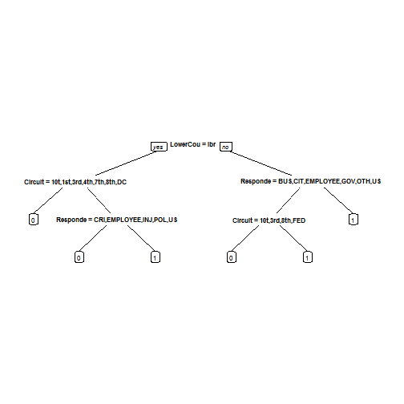

```r
StevensTree = rpart(Reverse ~ Circuit + Issue + Petitioner + Respondent + LowerCourt + Unconst, method="class", data =StevensTrain, minbucket=25)

prp(StevensTree)
```

### Predicting Supreme Court Decisions - bucket size selection

```r
set.seed(100)
spl = sample.split(StevensTrain$Reverse, SplitRatio = 0.5)
StevensValidateTrain = subset(StevensTrain, spl == TRUE)
StevensValidateTest = subset(StevensTrain, spl == FALSE)

StevensTree1 = rpart(Reverse ~ Circuit + Issue + Petitioner + Respondent + LowerCourt + Unconst, method="class", data = StevensValidateTrain, minbucket=5)
StevensTree2 = rpart(Reverse ~ Circuit + Issue + Petitioner + Respondent + LowerCourt + Unconst, method="class", data = StevensValidateTrain, minbucket=15)
StevensTree3 = rpart(Reverse ~ Circuit + Issue + Petitioner + Respondent + LowerCourt + Unconst, method="class", data = StevensValidateTrain, minbucket=25)

StevensPredict1 = predict(StevensTree1, newdata = StevensValidateTest, type="class")
StevensPredict2 = predict(StevensTree2, newdata = StevensValidateTest, type="class")
StevensPredict3 = predict(StevensTree3, newdata = StevensValidateTest, type="class")
```

### Predicting Supreme Court Decisions - Compare trees

```r
table(StevensValidateTest$Reverse, StevensPredict1) # 5
```

```
   StevensPredict1
     0  1
  0 52 38
  1 47 61
```

```r
table(StevensValidateTest$Reverse, StevensPredict2) # 15
```

```
   StevensPredict2
     0  1
  0 38 52
  1 28 80
```

```r
table(StevensValidateTest$Reverse, StevensPredict3) # 25
```

```
   StevensPredict3
     0  1
  0 64 26
  1 45 63
```

The best selection for min bucket is 25.

### Predicting Supreme Court Decisions - Final result

```r
StevensTreeFinal = rpart(Reverse ~ Circuit + Issue + Petitioner + Respondent + LowerCourt + Unconst, method="class", data =StevensTrain, minbucket=25)
StevensPredictTest = predict(StevensTreeFinal, newdata = StevensTest, type="class")

cmat = table(StevensTest$Reverse, StevensPredictTest)
cmat
```

```
   StevensPredictTest
     0  1
  0 36 41
  1 17 76
```

```r
c(cmat[1,1] + cmat[2,2], sum(cmat), (cmat[1,1] + cmat[2,2])/sum(cmat))
```

```
[1] 112.0000000 170.0000000   0.6588235
```

```r
# StevensPredictTest
```

We end up correctly predicting 112 out of the 170 cases in our test set, for an accuracy of 65:9%.

### Image Segmentation - Hierarchical Clustring

Analytics Edge Course Material

```r
flower = read.csv("flower.csv", header=FALSE)
str(flower)
```

```
'data.frame':   50 obs. of  50 variables:
 $ V1 : num  0.0991 0.0991 0.1034 0.1034 0.1034 ...
 $ V2 : num  0.112 0.108 0.112 0.116 0.108 ...
 $ V3 : num  0.134 0.116 0.121 0.116 0.112 ...
 $ V4 : num  0.138 0.138 0.121 0.121 0.112 ...
 $ V5 : num  0.138 0.134 0.125 0.116 0.112 ...
 $ V6 : num  0.138 0.129 0.121 0.108 0.112 ...
 $ V7 : num  0.129 0.116 0.103 0.108 0.112 ...
 $ V8 : num  0.116 0.103 0.103 0.103 0.116 ...
 $ V9 : num  0.1121 0.0991 0.1078 0.1121 0.1164 ...
 $ V10: num  0.121 0.108 0.112 0.116 0.125 ...
 $ V11: num  0.134 0.125 0.129 0.134 0.129 ...
 $ V12: num  0.147 0.134 0.138 0.129 0.138 ...
 $ V13: num  0.000862 0.146552 0.142241 0.142241 0.133621 ...
 $ V14: num  0.000862 0.000862 0.142241 0.133621 0.12931 ...
```

[output cut: 36 more lines]

### Image Segmentation - Data preperation

```r
flowerMatrix = as.matrix(flower)
str(flowerMatrix)
```

```
 num [1:50, 1:50] 0.0991 0.0991 0.1034 0.1034 0.1034 ...
 - attr(*, "dimnames")=List of 2
  ..$ : NULL
  ..$ : chr [1:50] "V1" "V2" "V3" "V4" ...
```

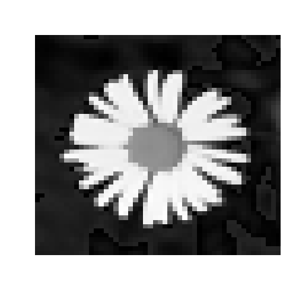

```r
image(flowerMatrix,axes=FALSE,col=grey(seq(0,1,length=256)))
```

```r
# Turn matrix into a vector
flowerVector = as.vector(flowerMatrix)
str(flowerVector)
```

```
 num [1:2500] 0.0991 0.0991 0.1034 0.1034 0.1034 ...
```

### Image Segmentation - Distances

**Genres:**

(unkonwn), Action, Adventure, Animation, Chilren's,

Comedy, Crime, Documnetary, Drama, Fantasy,

Film Noir, Horror, Musical, Mystery, Romance,

Sci-Fi, Thriller, War, Western

Toy Story: (0,0,0,1,1,1,0,0,0,0,0,0,0,0,0,0,0,0,0)

Batman Forever: (0,1,1,0,0,1,1,0,0,0,0,0,0,0,0,0,0,0,0)

### Image Segmentation - dendrogram

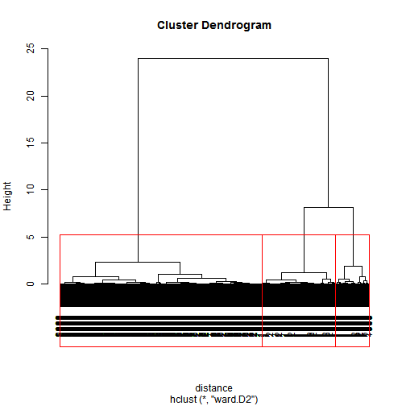

```r
#Compute "euclidean" distances

distance = dist(flowerVector, method = "euclidean")
# Hierarchical clustering of the intensity values which is the dendogram tree
clusterIntensity = hclust(distance, method="ward.D2")

#Plot the dendrogram
plot(clusterIntensity)

# Select 3 clusters
#visualising the cuts by plotting a rectangle around the clusters
rect.hclust(clusterIntensity, k = 3, border = "red")
```

### Image Segmentation - Split Clusters

```r
#lets split the data into these 3 clusters
flowerClusters = cutree(clusterIntensity, k = 3)
flowerClusters
```

```
   [1] 1 1 1 1 1 1 1 1 1 1 1 1 1 1 1 1 1 1 1 1 1 1 1 1 1 1 1 1 1 1 1 1 1 1
  [35] 1 1 1 1 1 1 1 1 1 1 1 1 1 1 1 1 1 1 1 1 1 1 1 1 1 1 1 1 1 1 1 1 1 1
  [69] 1 1 1 1 1 1 1 1 1 1 1 1 1 1 1 1 1 1 1 1 1 1 1 1 1 1 1 1 1 1 1 1 1 1
 [103] 1 1 1 1 1 1 1 1 1 1 1 1 1 1 1 1 1 1 1 1 1 1 1 1 1 1 1 1 1 1 1 1 1 1
 [137] 1 1 1 1 1 1 1 1 1 1 1 1 1 1 1 1 1 1 1 1 1 1 1 1 1 1 1 1 1 1 1 1 1 1
 [171] 1 1 1 1 1 1 1 1 1 1 1 1 1 1 1 1 1 1 1 1 1 1 1 1 1 1 1 1 1 1 1 1 1 1
 [205] 1 1 1 1 1 1 1 1 1 1 1 1 1 1 1 1 1 1 1 1 1 1 1 1 1 1 1 1 1 1 1 1 1 1
 [239] 1 1 1 1 1 1 1 1 1 1 1 1 1 1 1 1 1 1 1 1 1 1 1 1 1 1 1 1 1 1 1 1 1 1
 [273] 1 1 1 1 1 1 1 1 1 1 1 1 1 1 1 1 1 1 1 1 1 1 1 1 1 1 1 1 1 1 1 1 1 1
 [307] 1 1 1 1 1 1 1 1 1 1 1 1 1 1 1 1 2 2 1 1 1 1 1 1 1 1 1 1 1 1 1 1 1 1
 [341] 1 1 1 1 1 1 1 1 1 1 1 1 1 1 1 1 1 1 1 1 1 1 1 1 1 1 1 1 1 1 1 1 3 3
 [375] 2 2 3 2 1 1 1 1 1 1 1 1 1 1 1 1 1 1 1 1 1 1 1 1 1 1 1 1 1 1 1 1 1 1
 [409] 1 1 1 1 1 1 1 1 1 2 2 1 1 1 3 3 3 3 3 2 1 2 3 2 1 1 1 1 1 1 1 1 1 1
 [443] 1 1 1 1 1 1 1 1 1 1 1 1 1 1 1 1 1 1 1 1 1 1 1 1 1 3 3 1 1 1 3 3 3 3
 [477] 3 2 2 3 3 1 1 1 1 1 1 1 1 1 1 1 1 1 1 1 1 1 1 1 1 1 1 1 1 1 1 1 1 1
```

[output cut: 59 more lines]

### Image Segmentation - Plot

```r
# Find mean intensity values of each of these 3 clusters
tapply(flowerVector, flowerClusters, mean)
```

```
         1          2          3
0.08574315 0.50826255 0.93147713
```

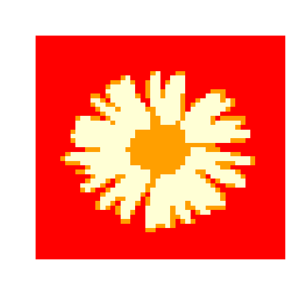

```r
# Plot the image and the clusters
#Before plotting the image we want to convert the flowerClusters vector into a matrix of form n x m using dim()
dim(flowerClusters) = c(50,50)
#plotting the image
image(flowerClusters, axes = FALSE)
```

### MRI Image - Analysis

```r
# Let's try this with an MRI image of the brain
#healthy.csv dataframe consists of matrix of intensity values
healthy = read.csv("healthy.csv", header=FALSE)

#Creating the healthy matrix
healthyMatrix = as.matrix(healthy)
str(healthyMatrix)
```

```
 num [1:566, 1:646] 0.00427 0.00855 0.01282 0.01282 0.01282 ...
 - attr(*, "dimnames")=List of 2
  ..$ : NULL
  ..$ : chr [1:646] "V1" "V2" "V3" "V4" ...
```

### MRI Image - Healthy Scan

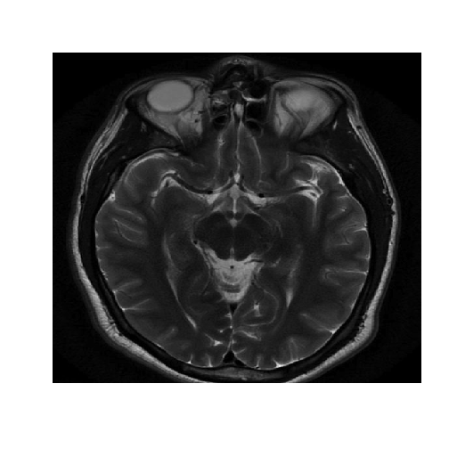

```r
#we can see that the image is 566 by 646 ... considerably larger than the flower

# Plot the image in gray scale
image(healthyMatrix,axes=FALSE,col=grey(seq(0,1,length=256)))
```

### MRI Image - # of cacluations

```r
# Hierarchial clustering  by computing the distance vector
healthyVector = as.vector(healthyMatrix)
#distance = dist(healthyVector, method = "euclidean")
#throws up error that the vector size is huge 480GB+

# We have an error - why?
#lets see the size of the vector
str(healthyVector)
```

```
 num [1:365636] 0.00427 0.00855 0.01282 0.01282 0.01282 ...
```

```r
#Lets  store the value in n
n=365636

#therefore the pairwise distance between each of the above n data points is:
n*(n-1)/2
```

```
[1] 66844659430
```

### MRI Image - Create K - Means clusters

```r
# Specify number of clusters (Depends upon what you want to extract from the image)
k = 5

# Run k-means
# k means clustering randomly assigns data points to cluster. Set a seed for similar results

set.seed(1)

KMC = kmeans(healthyVector, centers = k, iter.max = 1000)
str(KMC)
```

```
List of 9
 $ cluster     : int [1:365636] 3 3 3 3 3 3 3 3 3 3 ...
 $ centers     : num [1:5, 1] 0.4818 0.1062 0.0196 0.3094 0.1842
  ..- attr(*, "dimnames")=List of 2
  .. ..$ : chr [1:5] "1" "2" "3" "4" ...
  .. ..$ : NULL
 $ totss       : num 5775
 $ withinss    : num [1:5] 96.6 47.2 39.2 57.5 62.3
 $ tot.withinss: num 303
 $ betweenss   : num 5472
 $ size        : int [1:5] 20556 101085 133162 31555 79278
 $ iter        : int 2
 $ ifault      : int 0
 - attr(*, "class")= chr "kmeans"
```

### MRI Image - Plot segmented image

```r
# Extract clusters variable for plotting it
healthyClusters = KMC$cluster

# mean intensity values of each clusters is already available under the variable name centers in KMC object
KMC$centers[2] #mean intensity value of 2nd cluster
```

```
[1] 0.1061945
```

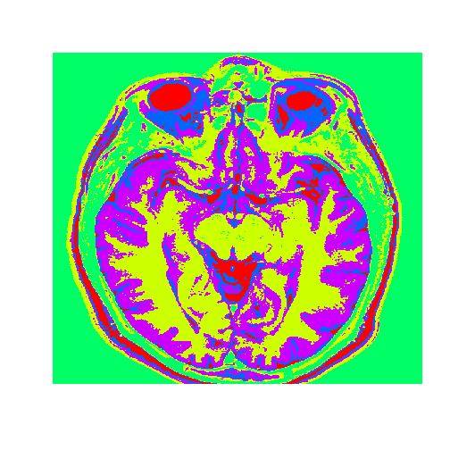

```r
# Plot the image with the clusters
#first convert into a matrix using dim()
dim(healthyClusters) = c(nrow(healthyMatrix), ncol(healthyMatrix))
image(healthyClusters, axes = FALSE, col=rainbow(k))
```

### MRI Image - Choosing # of Clusters

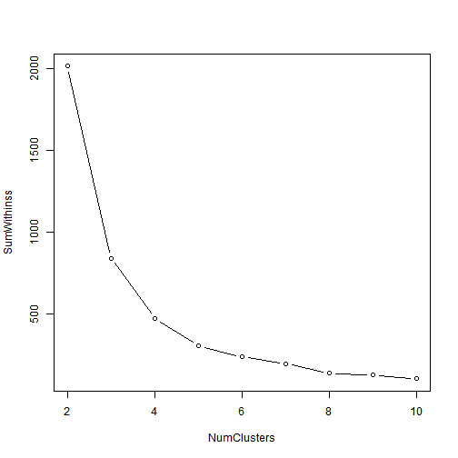

```r
# get the sum of withinss for cluseter size 2 to 10.
NumClusters = seq(2,10,1)
SumWithinss = sapply(2:10, function(x) sum(kmeans(healthyVector, centers=x, iter.max=1000)$withinss))

#SCREE plot
plot(NumClusters, SumWithinss, type="b")
```

### MRI Image - Compare with test image

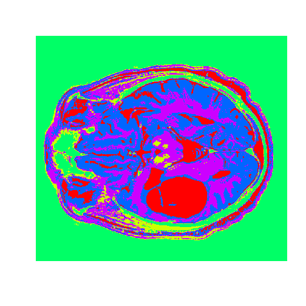

```r
tumor = read.csv("tumor.csv", header=FALSE)
tumorMatrix = as.matrix(tumor)
tumorVector = as.vector(tumorMatrix)

#Apply clusters from before to new image, using the flexclust package
#install.packages("flexclust")
library(flexclust)

#converting KMC into kcca object
KMC.kcca = as.kcca(KMC, healthyVector) #Healthy vector as a training set
tumorClusters = predict(KMC.kcca, newdata = tumorVector) #tumorvector as a testing set

#Visualize the clusters

#converting tumorClusters into a matrix
dim(tumorClusters) = c(nrow(tumorMatrix), ncol(tumorMatrix))

#visualising the tumorClusters
image(tumorClusters, axes = FALSE, col=rainbow(k))
```

### pySpark - compared to R

```r
weather = read.csv("daily_weather.csv")

#str(weather)
#summary(weather)
weather$low_humidity_day = as.numeric(weather$relative_humidity_3pm < 25)

library(caTools)
library(rpart)
library(rpart.plot)

set.seed(12345) # to get the same split everytime
spl = sample.split(weather$low_humidity_day, SplitRatio = 0.8)
train = subset(weather, spl==TRUE)
test = subset(weather, spl==FALSE)

weatherTree = rpart(low_humidity_day ~ air_pressure_9am + air_temp_9am + avg_wind_direction_9am + avg_wind_speed_9am + max_wind_direction_9am + max_wind_speed_9am + rain_accumulation_9am + rain_duration_9am, data=weather, method="class", minbucket=20)
# prp(weatherTree)

predictWeather = predict(weatherTree, newdata = test, type="class")
cmat = table(test$low_humidity_day, predictWeather)
cmat
```

```
   predictWeather
     0  1
  0 94 15
  1 20 90
```

```r
(cmat[1,1] + cmat[2,2])/sum(cmat)
```

```
[1] 0.8401826
```

### Acknowledgement

**Analytics Edge** https://www.edx.org/course/analytics-edge-mitx-15-071x-3

**Analytics Vidhya - learning plan** https://www.analyticsvidhya.com/blog/2017/01/the-most-comprehensive-data-science-learning-plan-for-2017/

**KNIME** https://www.knime.com/